# Growth Data with Dropout

craig

2026-04-26

This supplement presents `rblimp` R code and annotated output for the data analysis results reported in “Missing not at Random Analyses for Multilevel Data.” The OSF repository at https://osf.io/yegcf/ includes the paper and supporting documents, and the GitHub repository at https://github.com/craigenders/mnar-mlm includes executable R and Blimp Studio scripts for all examples.

The model numbers used throughout this supplement correspond to the models displayed in Tables 2 through 5 in the paper. The eight sensitivity models analyzed in this supplement are:

| Model | Description |
| --- | --- |
| **Model 1** | CMAR |
| **Model 2** | Shared Parameter Model With Random Effects Predicting Dropout |
| **Model 3** | Shared Parameter Model With Random Effects and Their Squares Predicting Dropout |
| **Model 4** | Shared Parameter Model With Random Effect Residuals Predicting Dropout |
| **Model 5** | Selection Model With Outcome and its Lag Predicting Dropout |
| **Model 6** | Selection Model With Outcome, its Square, and its Lag Predicting Dropout |
| **Model 7** | Selection Model With Residualized Outcome and its Lag Predicting Dropout |
| **Model 8** | Combined Model with Random Effects, Residualized Outcome and its Lag Predicting Dropout |

## rblimp Arguments

The table below summarizes the major `rblimp` function arguments used throughout this supplement. Each argument corresponds to a command in the Blimp Studio scripts provided on the project’s public GitHub site (https://github.com/craigenders/mnar-mlm). Readers unfamiliar with `rblimp` may find it helpful to use this table as a reference while working through the analysis examples.

| Argument | Description |
| --- | --- |
| `data` | R data frame containing all variables |
| `clusterid` | Level-2 identifier variable |
| `timeid` | Integer variable indexing repeated measurement occasions |
| `dropout` | Creates the missingness or dropout indicator |
| `latent` | Defines level-2 latent variables (random intercepts and slopes) |
| `fixed` | Completely observed predictor variables (speeds computation) |
| `center` | Specifies latent group mean centering for level-1 predictors |
| `model` | Specifies the focal outcome and missingness model regression equations |
| `parameters` | Defines custom derived quantities computed from model parameters |
| `nimps` | Number of imputations (required for computing model-predicted probabilities for graphing) |
| `seed` | Integer random number seed for reproducibility |
| `chains` | Number of independent MCMC chains (4 is also the default) |
| `burn` | Number of warm-up iterations per chain (discarded before estimation) |
| `iter` | Number of post-burn-in iterations used to compute parameter summaries |

## Reading the Output

The table below describes each section of the `rblimp` output in the order it appears. Detailed descriptions of the BURN-IN RHAT and OUTCOME MODEL ESTIMATES sections follow the table.

| Output Section | Description |
| --- | --- |
| `BURN-IN RHAT CONVERGENCE OUTPUT` | Assesses whether the MCMC warm-up period is sufficiently long; see detailed description below |
| `DATA INFORMATION` | Gives information about the sample size and missing data rates |
| `MODEL INFORMATION` | Reports the number of parameters and summarizes the fitted regression equations |
| `MODEL FIT` | Reports DIC and WAIC and custom Wald tests, if specified |
| `IMPUTED DATA SUMMARIES` | Reports summary statistics for every manifest and latent variable in the model |
| `CORRELATIONS AMONG RESIDUALS` | Reports correlations between pairs of residuals for a model’s outcome variables |
| `OUTCOME MODEL ESTIMATES` | Parameter estimates, standard errors, credible intervals, and diagnostics; see detailed description below |
| `GENERATED PARAMETERS` | Displays auxiliary parameters that are a function of the estimated parameters (e.g., mean difference, standardized mean difference) |

### Potential Scale Reduction Convergence Diagnostic

The potential scale reduction factor (PSRF) or Rhat convergence diagnostic appears near the top of the output. The PSRF assesses whether the MCMC warm-up period is sufficiently long for the algorithm to converge, which occurs when independent chains produce similar parameter estimates. Smaller values closer to the theoretical minimum of 1 are better, and values below 1.05 (Asparouhov & Muthén, 2010) or 1.10 (Gelman et al., 2014) are generally considered adequate. The “Highest PSR” column displays the highest (worst) value across all model parameters. This value should be less than 1.05 (or 1.10) by the end of the burn-in period (the final row of the table). If the highest PSRF is too large, increase the number of burn-in iterations (specified using the `burn` argument).

### Outcome Model Estimates

Each outcome variable has its own summary table containing raw and standardized coefficients, variances and standard deviations, and variance explained effect sizes. The Estimate column gives the point estimates (posterior median), the StdDev column displays “Bayesian standard errors” (posterior standard deviations), the 2.5% and 97.5% columns display 95% credible intervals. The ChiSq and PValue columns are frequentist significance tests (Wald chi-square values).

The tables for alpha (random intercept) and beta (random slope) summarize the focal model’s level-2 regression equations and random coefficient variation. The table for y displays the level-1 (within-person) residual variance.

The table for m displays the missingness model parameters. The missingness model’s pseudo-R2 (the proportion of variance explained on the latent response metric) is often the clearest indicator of model quality. Values around .70 or higher suggest that the predictors almost perfectly classify dropouts from completers, a condition known as near-separation. Very large effect sizes almost always signal that a model lacks support from the data.

### Effective Sample Size Diagnostic

The rightmost column in the parameter summary tables labeled N_Eff is the effective sample size (ESS) diagnostic. The ESS provides a gauge of whether the post-warm-up parameter summaries have sufficient precision. Numerically, it reflects the effective number of MCMC iterations (the “sample size”) that contribute to these summaries after accounting for autocorrelation in the sampling process. Values above 100 are generally considered adequate (Gelman et al., 2014, p. 287). Inadequate PSRF and ESS values indicate that more iterations are needed.

## Setup

### Load Packages

```r
library(ggplot2)
library(patchwork)
library(rblimp)
set_blimp('/applications/blimp/blimp-nightly')
```

### Read Data

```r
filepath1 <- 'https://raw.githubusercontent.com/craigenders/mnar-mlm/main/growth-dropout.csv'

growth_dropout <- read.csv(filepath1, stringsAsFactors = T)
```

### Source Plotting Functions

```r
source('https://raw.githubusercontent.com/blimp-stats/blimp-book/main/misc/functions.R')
source('https://raw.githubusercontent.com/craigenders/mnar-mlm/main/mnar-plotting.R')
```

### Helper Functions

```r
# function to extract key parameter estimates
extract_growth_params <- function(object, method) {

  tab <- object@estimates

  rows <- c(
    "alpha ~ Intercept",
    "beta ~ Intercept",
    "alpha ~ group",
    "beta ~ group",
    "alpha residual variance",
    "beta residual variance",
    "Cor( alpha, beta )",
    "y residual variance",
    "Parameter: diff",
    "Parameter: d_diff",
    "m R2: Coefficients"
  )

  res <- do.call(rbind, lapply(rows, function(r) {
    if (r %in% rownames(tab)) {
      round(tab[r, c("Estimate", "StdDev"), drop = FALSE], 2)
    } else {
      data.frame(Estimate = NA_real_, StdDev = NA_real_, row.names = r)
    }
  }))

  rownames(res) <- c(
    "Icept (G = 0)",
    "Slope (G = 0)",
    "Icept Diff.",
    "Slope Diff.",
    "Var(Icept)",
    "Var(Slope)",
    "Cor(Icept, Slope)",
    "Var(Residual)",
    "Mean Diff.",
    "Std. Diff.",
    "Pseudo-Rsq"
  )

  colnames(res) <- c(
    paste0("Est_", method),
    paste0("SE_", method)
  )

  res
}

# function to extract convergence diagnostics
extract_convergence <- function(object, method) {

  neff <- object@estimates[, "N_Eff"]
  neff <- neff[is.finite(neff)]

  psr_row <- as.numeric(object@psr[20, ])
  psr_row <- psr_row[is.finite(psr_row)]

  data.frame(
    Min_Neff = round(min(neff),    3),
    Max_Neff = round(max(neff),    3),
    Min_PSR  = round(min(psr_row), 3),
    Max_PSR  = round(max(psr_row), 3),
    row.names = method
  )
}
```

# Model 1: CMAR

Model 1 fits a two-level growth curve under the conditionally missing at random (CMAR) assumption. This model serves as the baseline against which the MNAR models are compared.

```r
model1 <- rblimp(
  data = growth_dropout,
  clusterid = 'l2id',
  timeid = 'time',
  dropout = 'm = y (monotone)',
  latent = 'l2id = alpha beta',
  fixed = 'group time',
  model = '
    level2:
    alpha ~ intercept@g0a group@g1a;
    beta ~ intercept@g0b group@g1b;
    alpha ~~ beta;
    level1:
    y ~ intercept@alpha time@beta;',
  parameters = '
    diff = (((g0a+g1a)  + 4*(g0b+g1b)) - (g0a + 4*g0b));
    d_diff = diff / sqrt(y.totalvar + alpha.totalvar);',
  seed = 90291,
  chains = 4,
  burn = 25000,
  iter = 25000)

output(model1)
```

```
---------------------------------------------------------------------------

                                   Blimp
                              4.0.3-nightly9

             Blimp was developed with funding from Institute of
           Education Sciences awards R305D150056 and R305D190002.

            Craig K. Enders, P.I. Email: cenders@psych.ucla.edu
           Brian T. Keller, Co-P.I. Email: btkeller@missouri.edu
                 Han Du, Co-P.I. Email: hdu@psych.ucla.edu
                 Roy Levy, Co-P.I. Email: roy.levy@asu.edu

              Programming and Blimp Studio by Brian T. Keller

                   There is no expressed license given.

---------------------------------------------------------------------------


ALGORITHMIC OPTIONS SPECIFIED:

  Imputation method:                 Fully Bayesian model-based
  MCMC algorithm:                    Full conditional Metropolis sampler with
                                       Auto-Derived Conditional Distributions
  Default Priors:
    Multilevel covariance matrices:  Zero matrix, df = -(p + 1) (PRIOR2)
    Outcome covariance matrices:     Zero matrix, df = -(p + 1) (PRIOR2)
    Predictor model variances:       Unit sum of squares, df = 2 (XPRIOR1)
  Chain Starting Values:             Random starting values


  NOTE: For complete list of priors include 'pinfo' in the options.


BURN-IN RHAT CONVERGENCE DIAGNOSTIC OUTPUT:

  NOTE: Rank-normalized Rhat (Vehtari et al., 2021) is being used.
        This applies rank normalization and chain folding for robust
        convergence detection across all chains.
```

[output cut: 207 more lines]

```


GENERATED PARAMETERS:

  Summaries based on 25000 iterations using 4 chains.
  NOTE: Estimate column based on posterior median.


Parameters                         Estimate     StdDev       2.5%      97.5%      ChiSq     PValue      N_Eff
                                ------------------------------------------------------------------------------

  diff                               -3.352      0.189     -3.723     -2.982    315.850      0.000   6673.895
  d_diff                             -1.520      0.082     -1.681     -1.358    341.394      0.000   7556.501

                                ------------------------------------------------------------------------------
```

# Missingness Probabilities

## Linear Missingness

*Important features of the missingness model:*

- The `@` symbol fixes parameters at specific numeric values (e.g., -3 for the fixed intercept and 0 for the random intercept variance after the vertical pipe).

```r
time_linear <- rblimp(
  data = growth_dropout,
  clusterid = 'l2id',
  timeid = 'time',
  dropout = 'm = y (monotone)',
  latent = 'l2id = alpha beta',
  fixed = 'time group',
  model = '
    level2:
    alpha ~ intercept group;
    beta ~ intercept group;
    alpha ~~ beta;
    level1:
    y ~ intercept@alpha time@beta;
    missingness:
    m ~ intercept@-3 time@b1 time*group@b2 | intercept@0;',
  seed = 90291,
  chains = 4,
  burn = 25000,
  iter = 25000)

output(time_linear)
```

```
---------------------------------------------------------------------------

                                   Blimp
                              4.0.3-nightly9

             Blimp was developed with funding from Institute of
           Education Sciences awards R305D150056 and R305D190002.

            Craig K. Enders, P.I. Email: cenders@psych.ucla.edu
           Brian T. Keller, Co-P.I. Email: btkeller@missouri.edu
                 Han Du, Co-P.I. Email: hdu@psych.ucla.edu
                 Roy Levy, Co-P.I. Email: roy.levy@asu.edu

              Programming and Blimp Studio by Brian T. Keller

                   There is no expressed license given.

---------------------------------------------------------------------------


ALGORITHMIC OPTIONS SPECIFIED:

  Imputation method:                 Fully Bayesian model-based
  MCMC algorithm:                    Full conditional Metropolis sampler with
                                       Auto-Derived Conditional Distributions
  Default Priors:
    Multilevel covariance matrices:  Zero matrix, df = -(p + 1) (PRIOR2)
    Outcome covariance matrices:     Zero matrix, df = -(p + 1) (PRIOR2)
    Predictor model variances:       Unit sum of squares, df = 2 (XPRIOR1)
  Chain Starting Values:             Random starting values


  NOTE: For complete list of priors include 'pinfo' in the options.


BURN-IN RHAT CONVERGENCE DIAGNOSTIC OUTPUT:

  NOTE: Rank-normalized Rhat (Vehtari et al., 2021) is being used.
        This applies rank normalization and chain folding for robust
        convergence detection across all chains.
```

[output cut: 234 more lines]

```
Thresholds:
  Tau 1                               0.000      0.000      0.000      0.000        ---        ---        nan

Standard Deviations:
  Residual SD                         1.000      0.000      1.000      1.000        ---        ---        nan

Standardized Coefficients:
  time                                0.657      0.017      0.623      0.689   1508.203      0.000   7658.285
  time*group                          0.062      0.027      0.009      0.115      5.348      0.021   7955.648

Proportion Variance Explained
  by Coefficients                     0.478      0.010      0.457      0.497        ---        ---   8450.258
  by Residual Variation               0.522      0.010      0.503      0.543        ---        ---   8450.258

                                ------------------------------------------------------------------------------
```

## Quadratic Missingness

The model in this section extends the linear trend by adding a quadratic time term, allowing missingness rates to accelerate or decelerate across occasions.

*Important features of the missingness model:*

- The `@` symbol fixes parameters at specific numeric values (e.g., -3 for the fixed intercept and 0 for the random intercept variance after the vertical pipe).
- Squared terms are specified using `^2`.

```r
time_quadratic <- rblimp(
  data = growth_dropout,
  clusterid = 'l2id',
  timeid = 'time',
  dropout = 'm = y (monotone)',
  latent = 'l2id = alpha beta',
  fixed = 'time group',
  model = '
    level2:
    alpha ~ intercept group;
    beta ~ intercept group;
    alpha ~~ beta;
    level1:
    y ~ intercept@alpha time@beta;
    missingness:
    m ~ intercept@-3 time time^2 time*group time^2*group | intercept@0;',
  seed = 90291,
  chains = 4,
  burn = 25000,
  iter = 25000)

output(time_quadratic)
```

```
---------------------------------------------------------------------------

                                   Blimp
                              4.0.3-nightly9

             Blimp was developed with funding from Institute of
           Education Sciences awards R305D150056 and R305D190002.

            Craig K. Enders, P.I. Email: cenders@psych.ucla.edu
           Brian T. Keller, Co-P.I. Email: btkeller@missouri.edu
                 Han Du, Co-P.I. Email: hdu@psych.ucla.edu
                 Roy Levy, Co-P.I. Email: roy.levy@asu.edu

              Programming and Blimp Studio by Brian T. Keller

                   There is no expressed license given.

---------------------------------------------------------------------------


ALGORITHMIC OPTIONS SPECIFIED:

  Imputation method:                 Fully Bayesian model-based
  MCMC algorithm:                    Full conditional Metropolis sampler with
                                       Auto-Derived Conditional Distributions
  Default Priors:
    Multilevel covariance matrices:  Zero matrix, df = -(p + 1) (PRIOR2)
    Outcome covariance matrices:     Zero matrix, df = -(p + 1) (PRIOR2)
    Predictor model variances:       Unit sum of squares, df = 2 (XPRIOR1)
  Chain Starting Values:             Random starting values


  NOTE: For complete list of priors include 'pinfo' in the options.


BURN-IN RHAT CONVERGENCE DIAGNOSTIC OUTPUT:

  NOTE: Rank-normalized Rhat (Vehtari et al., 2021) is being used.
        This applies rank normalization and chain folding for robust
        convergence detection across all chains.
```

[output cut: 238 more lines]

```

Standard Deviations:
  Residual SD                         1.000      0.000      1.000      1.000        ---        ---        nan

Standardized Coefficients:
  time                                1.525      0.084      1.357      1.688    326.961      0.000   6139.024
  time^2                             -1.021      0.103     -1.224     -0.819     98.879      0.000   6228.365
  time*group                          0.560      0.106      0.350      0.765     27.817      0.000   6473.882
  time^2*group                       -0.569      0.115     -0.791     -0.342     24.456      0.000   6204.193

Proportion Variance Explained
  by Coefficients                     0.459      0.009      0.441      0.477        ---        ---   7977.259
  by Residual Variation               0.541      0.009      0.523      0.559        ---        ---   7977.259

                                ------------------------------------------------------------------------------
```

## Dummy-Coded Missingness

The model in this section uses dummy codes for each time point to estimate occasion-specific missingness probabilities freely, without imposing a functional form on how rates change over time.

*Important features of the missingness model:*

- The `@` symbol fixes parameters at specific numeric values (e.g., -3 for the fixed intercept and 0 for the random intercept variance after the vertical pipe).
- Boolean statements create dummy codes as functions of the TIME variable, such that each condition in parentheses returns 1 if TIME = `t` and 0 otherwise.
- A looping structure avoids specifying a separate Boolean statement for each occasion.

```r
time_dummy <- rblimp(
  data = growth_dropout,
  clusterid = 'l2id',
  timeid = 'time',
  dropout = 'm = y (monotone)',
  latent = 'l2id = alpha beta',
  fixed = 'time group',
  model = '
    level2:
    alpha ~ intercept@g0a group@g1a;
    beta ~ intercept@g0b group@g1b;
    alpha ~~ beta;
    level1:
    y ~ intercept@alpha time@beta;
    missingness:
    m ~ intercept@-3 | intercept@0;
    { t in 1:4 } : m ~ (time == [t]) (time == [t])*group;',
  parameters = '
    diff = (((g0a+g1a)  + 4*(g0b+g1b)) - (g0a + 4*g0b));
    d_diff = diff / sqrt(y.totalvar + alpha.totalvar);',
  seed = 90291,
  chains = 4,
  burn = 25000,
  iter = 25000)

output(time_dummy)
```

```
---------------------------------------------------------------------------

                                   Blimp
                              4.0.3-nightly9

             Blimp was developed with funding from Institute of
           Education Sciences awards R305D150056 and R305D190002.

            Craig K. Enders, P.I. Email: cenders@psych.ucla.edu
           Brian T. Keller, Co-P.I. Email: btkeller@missouri.edu
                 Han Du, Co-P.I. Email: hdu@psych.ucla.edu
                 Roy Levy, Co-P.I. Email: roy.levy@asu.edu

              Programming and Blimp Studio by Brian T. Keller

                   There is no expressed license given.

---------------------------------------------------------------------------


ALGORITHMIC OPTIONS SPECIFIED:

  Imputation method:                 Fully Bayesian model-based
  MCMC algorithm:                    Full conditional Metropolis sampler with
                                       Auto-Derived Conditional Distributions
  Default Priors:
    Multilevel covariance matrices:  Zero matrix, df = -(p + 1) (PRIOR2)
    Outcome covariance matrices:     Zero matrix, df = -(p + 1) (PRIOR2)
    Predictor model variances:       Unit sum of squares, df = 2 (XPRIOR1)
  Chain Starting Values:             Random starting values


  NOTE: For complete list of priors include 'pinfo' in the options.


BURN-IN RHAT CONVERGENCE DIAGNOSTIC OUTPUT:

  NOTE: Rank-normalized Rhat (Vehtari et al., 2021) is being used.
        This applies rank normalization and chain folding for robust
        convergence detection across all chains.
```

[output cut: 268 more lines]

```


GENERATED PARAMETERS:

  Summaries based on 25000 iterations using 4 chains.
  NOTE: Estimate column based on posterior median.


Parameters                         Estimate     StdDev       2.5%      97.5%      ChiSq     PValue      N_Eff
                                ------------------------------------------------------------------------------

  diff                               -3.351      0.188     -3.716     -2.976    317.646      0.000   6010.762
  d_diff                             -1.518      0.082     -1.678     -1.356    342.152      0.000   6997.221

                                ------------------------------------------------------------------------------
```

## Missingness Probability Plots

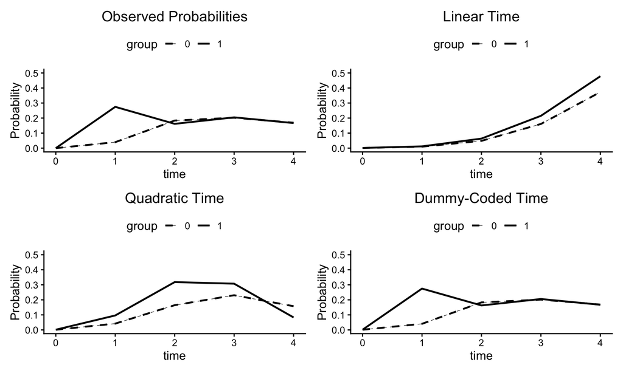

```r
ymax <- .5
ymin <- 0

plot_pmiss_obs <- plot_means(m ~ time | group,
    model = time_dummy,
    ylab = "Probability",
    title = "Observed Probabilities",
    group_labels = c("0" = "0", "1" = "1")) + ylim(ymin, ymax) +
    theme(legend.position = "top", legend.justification = "center") +
    scale_linetype_manual(values = c("dashed", "solid")) +
    geom_line(linewidth = .25)

plot_pmiss_linear <- plot_means(m.1.probability ~ time | group,
    model = time_linear,
    ylab = "Probability",
    title = "Linear Time",
    group_labels = c("0" = "0", "1" = "1")) + ylim(ymin, ymax) +
    theme(legend.position = "top", legend.justification = "center") +
    scale_linetype_manual(values = c("dashed", "solid")) +
    geom_line(linewidth = .25)

plot_pmiss_quadratic <- plot_means(m.1.probability ~ time | group,
    model = time_quadratic,
    ylab = "Probability",
    title = "Quadratic Time",
    group_labels = c("0" = "0", "1" = "1")) + ylim(ymin, ymax) +
    theme(legend.position = "top", legend.justification = "center") +
    scale_linetype_manual(values = c("dashed", "solid")) +
    geom_line(linewidth = .25)

plot_pmiss_dummy <- plot_means(m.1.probability ~ time | group,
    model = time_dummy,
    ylab = "Probability",
    title = "Dummy-Coded Time",
    group_labels = c("0" = "0", "1" = "1")) + ylim(ymin, ymax) +
    theme(legend.position = "top", legend.justification = "center") +
    scale_linetype_manual(values = c("dashed", "solid")) +
    geom_line(linewidth = .25)

plot_pmiss <- (plot_pmiss_obs | plot_pmiss_linear) / (plot_pmiss_quadratic | plot_pmiss_dummy)
plot_pmiss
```

## Probability Comparison

The table below compares observed missingness probabilities to model-predicted probabilities from the linear, quadratic, and dummy-coded time models.

```r
pmiss_obs       <- aggregate(m ~ time + group,               data = time_dummy@average_imp,     mean)
pmiss_linear    <- aggregate(m.1.probability ~ time + group, data = time_linear@average_imp,    mean)
pmiss_quadratic <- aggregate(m.1.probability ~ time + group, data = time_quadratic@average_imp, mean)
pmiss_dummy     <- aggregate(m.1.probability ~ time + group, data = time_dummy@average_imp,     mean)

rmse_pmiss_linear    <- sqrt(mean((pmiss_linear$m.1.probability    - pmiss_obs$m)^2))
rmse_pmiss_quadratic <- sqrt(mean((pmiss_quadratic$m.1.probability - pmiss_obs$m)^2))
rmse_pmiss_dummy     <- sqrt(mean((pmiss_dummy$m.1.probability     - pmiss_obs$m)^2))

miss_fit <- data.frame(
  RMSE   = round(c(rmse_pmiss_linear, rmse_pmiss_quadratic, rmse_pmiss_dummy), 3),
  Min    = round(c(
    min(pmiss_linear$m.1.probability    - pmiss_obs$m),
    min(pmiss_quadratic$m.1.probability - pmiss_obs$m),
    min(pmiss_dummy$m.1.probability     - pmiss_obs$m)), 3),
  Median = round(c(
    median(pmiss_linear$m.1.probability    - pmiss_obs$m),
    median(pmiss_quadratic$m.1.probability - pmiss_obs$m),
    median(pmiss_dummy$m.1.probability     - pmiss_obs$m)), 3),
  Mean   = round(c(
    mean(pmiss_linear$m.1.probability    - pmiss_obs$m),
    mean(pmiss_quadratic$m.1.probability - pmiss_obs$m),
    mean(pmiss_dummy$m.1.probability     - pmiss_obs$m)), 3),
  Max    = round(c(
    max(pmiss_linear$m.1.probability    - pmiss_obs$m),
    max(pmiss_quadratic$m.1.probability - pmiss_obs$m),
    max(pmiss_dummy$m.1.probability     - pmiss_obs$m)), 3),
  row.names = c("Linear", "Quadratic", "Dummy")
)
```

Missingness Model Fit

|  | RMSE | Min | Median | Mean | Max |
| --- | --- | --- | --- | --- | --- |
| Linear | 0.154 | -0.263 | -0.014 | -0.004 | 0.312 |
| Quadratic | 0.087 | -0.179 | 0.001 | 0.000 | 0.156 |
| Dummy | 0.001 | -0.001 | 0.001 | 0.000 | 0.001 |

# Model 2: Shared Parameter

Model 2 is a shared parameter model that links the probability of missingness to each person’s random intercept and slope, so that individuals with higher or lower trajectories have systematically different rates of missing data. Because scores are complete at baseline, the missingness model uses interactions with a time-varying dummy code to activate effects at occasions with missing data.

*Important features of the missingness model:*

- A definition variable creates the time-varying dummy code that activates effects at occasions with missing data; this expression is substituted into the missingness model to make the specification more compact.
- The `@` symbol fixes parameters at specific numeric values (e.g., -3 for the fixed intercept and 0 for the random intercept variance after the vertical pipe).
- Boolean statements create dummy codes as functions of the TIME variable, such that each condition in parentheses returns 1 if TIME = `t` and 0 otherwise.
- A looping structure avoids specifying a separate Boolean statement for each occasion.

```r
model2 <- rblimp(
  data = growth_dropout,
  clusterid = 'l2id',
  timeid = 'time',
  dropout = 'm = y (monotone)',
  latent = 'l2id = alpha beta',
  fixed = 'group time',
  model = '
    level2:
    alpha ~ intercept@g0a group@g1a;
    beta ~ intercept@g0b group@g1b;
    alpha ~~ beta;
    level1:
    y ~ intercept@alpha time@beta;
    missingness:
    d = ifelse(time < 1, 0, 1);
    m ~ intercept@-3 alpha*d beta*d | intercept@0;
    { t in 1:4 } : m ~ (time == [t]) (time == [t])*group;',
  parameters = '
    diff = (((g0a+g1a)  + 4*(g0b+g1b)) - (g0a + 4*g0b));
    d_diff = diff / sqrt(y.totalvar + alpha.totalvar);',
  seed = 90291,
  chains = 4,
  burn = 25000,
  iter = 25000)

output(model2)
```

```
---------------------------------------------------------------------------

                                   Blimp
                              4.0.3-nightly9

             Blimp was developed with funding from Institute of
           Education Sciences awards R305D150056 and R305D190002.

            Craig K. Enders, P.I. Email: cenders@psych.ucla.edu
           Brian T. Keller, Co-P.I. Email: btkeller@missouri.edu
                 Han Du, Co-P.I. Email: hdu@psych.ucla.edu
                 Roy Levy, Co-P.I. Email: roy.levy@asu.edu

              Programming and Blimp Studio by Brian T. Keller

                   There is no expressed license given.

---------------------------------------------------------------------------


ALGORITHMIC OPTIONS SPECIFIED:

  Imputation method:                 Fully Bayesian model-based
  MCMC algorithm:                    Full conditional Metropolis sampler with
                                       Auto-Derived Conditional Distributions
  Default Priors:
    Multilevel covariance matrices:  Zero matrix, df = -(p + 1) (PRIOR2)
    Outcome covariance matrices:     Zero matrix, df = -(p + 1) (PRIOR2)
    Predictor model variances:       Unit sum of squares, df = 2 (XPRIOR1)
  Chain Starting Values:             Random starting values


  NOTE: For complete list of priors include 'pinfo' in the options.


BURN-IN RHAT CONVERGENCE DIAGNOSTIC OUTPUT:

  NOTE: Rank-normalized Rhat (Vehtari et al., 2021) is being used.
        This applies rank normalization and chain folding for robust
        convergence detection across all chains.
```

[output cut: 276 more lines]

```


GENERATED PARAMETERS:

  Summaries based on 25000 iterations using 4 chains.
  NOTE: Estimate column based on posterior median.


Parameters                         Estimate     StdDev       2.5%      97.5%      ChiSq     PValue      N_Eff
                                ------------------------------------------------------------------------------

  diff                               -3.095      0.205     -3.489     -2.685    226.803      0.000   3513.200
  d_diff                             -1.424      0.092     -1.601     -1.241    241.452      0.000   4164.314

                                ------------------------------------------------------------------------------
```

# Model 3: Shared Parameter

Model 3 extends the shared parameter model by adding quadratic terms for the random intercept and slope in the missingness equation, allowing for nonlinear dependence of missingness on trajectory characteristics. Because scores are complete at baseline, the missingness model uses interactions with a time-varying dummy code to activate effects at occasions with missing data.

*Important features of the missingness model:*

- A definition variable creates the time-varying dummy code that activates effects at occasions with missing data; this expression is substituted into the missingness model to make the specification more compact.
- The `@` symbol fixes parameters at specific numeric values (e.g., -3 for the fixed intercept and 0 for the random intercept variance after the vertical pipe).
- Boolean statements create dummy codes as functions of the TIME variable, such that each condition in parentheses returns 1 if TIME = `t` and 0 otherwise.
- A looping structure avoids specifying a separate Boolean statement for each occasion.
- Squared terms are specified using `^2`.

```r
model3 <- rblimp(
  data = growth_dropout,
  clusterid = 'l2id',
  timeid = 'time',
  dropout = 'm = y (monotone)',
  latent = 'l2id = alpha beta',
  fixed = 'group time',
  model = '
    level2:
    alpha ~ intercept@g0a group@g1a;
    beta ~ intercept@g0b group@g1b;
    alpha ~~ beta;
    level1:
    y ~ intercept@alpha time@beta;
    missingness:
    d = ifelse(time < 1, 0, 1);
    m ~ intercept@-3 alpha*d alpha*d^2 beta*d beta*d^2 | intercept@0;
    { t in 1:4 } : m ~ (time == [t]) (time == [t])*group;',
  parameters = '
    diff = (((g0a+g1a)  + 4*(g0b+g1b)) - (g0a + 4*g0b));
    d_diff = diff / sqrt(y.totalvar + alpha.totalvar);',
  seed = 90291,
  chains = 4,
  burn = 25000,
  iter = 25000)

output(model3)
```

```
---------------------------------------------------------------------------

                                   Blimp
                              4.0.3-nightly9

             Blimp was developed with funding from Institute of
           Education Sciences awards R305D150056 and R305D190002.

            Craig K. Enders, P.I. Email: cenders@psych.ucla.edu
           Brian T. Keller, Co-P.I. Email: btkeller@missouri.edu
                 Han Du, Co-P.I. Email: hdu@psych.ucla.edu
                 Roy Levy, Co-P.I. Email: roy.levy@asu.edu

              Programming and Blimp Studio by Brian T. Keller

                   There is no expressed license given.

---------------------------------------------------------------------------


ALGORITHMIC OPTIONS SPECIFIED:

  Imputation method:                 Fully Bayesian model-based
  MCMC algorithm:                    Full conditional Metropolis sampler with
                                       Auto-Derived Conditional Distributions
  Default Priors:
    Multilevel covariance matrices:  Zero matrix, df = -(p + 1) (PRIOR2)
    Outcome covariance matrices:     Zero matrix, df = -(p + 1) (PRIOR2)
    Predictor model variances:       Unit sum of squares, df = 2 (XPRIOR1)
  Chain Starting Values:             Random starting values


  NOTE: For complete list of priors include 'pinfo' in the options.


BURN-IN RHAT CONVERGENCE DIAGNOSTIC OUTPUT:

  NOTE: Rank-normalized Rhat (Vehtari et al., 2021) is being used.
        This applies rank normalization and chain folding for robust
        convergence detection across all chains.
```

[output cut: 280 more lines]

```


GENERATED PARAMETERS:

  Summaries based on 25000 iterations using 4 chains.
  NOTE: Estimate column based on posterior median.


Parameters                         Estimate     StdDev       2.5%      97.5%      ChiSq     PValue      N_Eff
                                ------------------------------------------------------------------------------

  diff                               -3.093      0.203     -3.492     -2.693    232.530      0.000   4505.592
  d_diff                             -1.424      0.090     -1.600     -1.245    247.723      0.000   5330.354

                                ------------------------------------------------------------------------------
```

# Model 4: Shared Parameter

Model 4 reformulates the shared parameter model using random intercept and slope residuals rather than raw latent variable values, separating the MNAR mechanism into a component that is orthogonal to the grouping variable. Because scores are complete at baseline, the missingness model uses interactions with a time-varying dummy code to activate effects at occasions with missing data. This model uses `burn = 200000` and `iter = 200000` to achieve adequate convergence.

*Important features of the missingness model:*

- A definition variable creates the time-varying dummy code that activates effects at occasions with missing data.
- Definition variables also define the random intercept and slope residuals; these expressions are substituted into the missingness model to make the specification more compact.
- The `@` symbol fixes parameters at specific numeric values (e.g., -3 for the fixed intercept and 0 for the random intercept variance after the vertical pipe).
- Boolean statements create dummy codes as functions of the TIME variable, such that each condition in parentheses returns 1 if TIME = `t` and 0 otherwise.
- A looping structure avoids specifying a separate Boolean statement for each occasion.

```r
model4 <- rblimp(
  data = growth_dropout,
  clusterid = 'l2id',
  timeid = 'time',
  dropout = 'm = y (monotone)',
  latent = 'l2id = alpha beta',
  fixed = 'group time',
  model = '
    level2:
    alpha ~ intercept@g0a group@g1a;
    beta ~ intercept@g0b group@g1b;
    alpha ~~ beta;
    level1:
    y ~ intercept@alpha time@beta;
    missingness:
    alpha_res = alpha - (g0a + g1a*group);
    beta_res = beta - (g0b + g1b*group);
    d = ifelse(time < 1, 0, 1);
    m ~ intercept@-3 alpha_res*d beta_res*d | intercept@0;
    { t in 1:4 } : m ~ (time == [t]) (time == [t])*group;',
  parameters = '
    diff = (((g0a+g1a)  + 4*(g0b+g1b)) - (g0a + 4*g0b));
    d_diff = diff / sqrt(y.totalvar + alpha.totalvar);',
  seed = 90291,
  chains = 4,
  burn = 200000,
  iter = 200000)

output(model4)
```

```
---------------------------------------------------------------------------

                                   Blimp
                              4.0.3-nightly9

             Blimp was developed with funding from Institute of
           Education Sciences awards R305D150056 and R305D190002.

            Craig K. Enders, P.I. Email: cenders@psych.ucla.edu
           Brian T. Keller, Co-P.I. Email: btkeller@missouri.edu
                 Han Du, Co-P.I. Email: hdu@psych.ucla.edu
                 Roy Levy, Co-P.I. Email: roy.levy@asu.edu

              Programming and Blimp Studio by Brian T. Keller

                   There is no expressed license given.

---------------------------------------------------------------------------


ALGORITHMIC OPTIONS SPECIFIED:

  Imputation method:                 Fully Bayesian model-based
  MCMC algorithm:                    Full conditional Metropolis sampler with
                                       Auto-Derived Conditional Distributions
  Default Priors:
    Multilevel covariance matrices:  Zero matrix, df = -(p + 1) (PRIOR2)
    Outcome covariance matrices:     Zero matrix, df = -(p + 1) (PRIOR2)
    Predictor model variances:       Unit sum of squares, df = 2 (XPRIOR1)
  Chain Starting Values:             Random starting values


  NOTE: For complete list of priors include 'pinfo' in the options.


BURN-IN RHAT CONVERGENCE DIAGNOSTIC OUTPUT:

  NOTE: Rank-normalized Rhat (Vehtari et al., 2021) is being used.
        This applies rank normalization and chain folding for robust
        convergence detection across all chains.
```

[output cut: 278 more lines]

```


GENERATED PARAMETERS:

  Summaries based on 200000 iterations using 4 chains.
  NOTE: Estimate column based on posterior median.


Parameters                         Estimate     StdDev       2.5%      97.5%      ChiSq     PValue      N_Eff
                                ------------------------------------------------------------------------------

  diff                               -3.106      0.199     -3.496     -2.714    242.625      0.000  16384.846
  d_diff                             -1.445      0.090     -1.620     -1.266    256.219      0.000  15543.952

                                ------------------------------------------------------------------------------
```

# Model 5: Selection Model

Model 5 is a Diggle-Kenward selection model that conditions the probability of missingness on the current and lagged outcome values. Because scores are complete at baseline, the missingness model uses interactions with a time-varying dummy code to activate effects at occasions with missing data.

*Important features of the missingness model:*

- A definition variable creates the time-varying dummy code that activates effects at occasions with missing data; this expression is substituted into the missingness model to make the specification more compact.
- The `@` symbol fixes parameters at specific numeric values (e.g., -3 for the fixed intercept and 0 for the random intercept variance after the vertical pipe).
- Boolean statements create dummy codes as functions of the TIME variable, such that each condition in parentheses returns 1 if TIME = `t` and 0 otherwise.
- A looping structure avoids specifying a separate Boolean statement for each occasion.
- Appending `.lag` to a variable’s name introduces its lag into the model.

```r
model5 <- rblimp(
  data = growth_dropout,
  clusterid = 'l2id',
  timeid = 'time',
  dropout = 'm = y (monotone)',
  latent = 'l2id = alpha beta',
  fixed = 'group time',
  model = '
    level2:
    alpha ~ intercept@g0a group@g1a;
    beta ~ intercept@g0b group@g1b;
    alpha ~~ beta;
    level1:
    y ~ intercept@alpha time@beta;
    missingness:
    d = ifelse(time < 1, 0, 1);
    m ~ intercept@-3 y*d y.lag*d | intercept@0;
    { t in 1:4 } : m ~ (time == [t]) (time == [t])*group;',
  parameters = '
    diff = (((g0a+g1a)  + 4*(g0b+g1b)) - (g0a + 4*g0b));
    d_diff = diff / sqrt(y.totalvar + alpha.totalvar);',
  seed = 90291,
  chains = 4,
  burn = 25000,
  iter = 25000)

output(model5)
```

```
---------------------------------------------------------------------------

                                   Blimp
                              4.0.3-nightly9

             Blimp was developed with funding from Institute of
           Education Sciences awards R305D150056 and R305D190002.

            Craig K. Enders, P.I. Email: cenders@psych.ucla.edu
           Brian T. Keller, Co-P.I. Email: btkeller@missouri.edu
                 Han Du, Co-P.I. Email: hdu@psych.ucla.edu
                 Roy Levy, Co-P.I. Email: roy.levy@asu.edu

              Programming and Blimp Studio by Brian T. Keller

                   There is no expressed license given.

---------------------------------------------------------------------------


ALGORITHMIC OPTIONS SPECIFIED:

  Imputation method:                 Fully Bayesian model-based
  MCMC algorithm:                    Full conditional Metropolis sampler with
                                       Auto-Derived Conditional Distributions
  Default Priors:
    Multilevel covariance matrices:  Zero matrix, df = -(p + 1) (PRIOR2)
    Outcome covariance matrices:     Zero matrix, df = -(p + 1) (PRIOR2)
    Predictor model variances:       Unit sum of squares, df = 2 (XPRIOR1)
  Chain Starting Values:             Random starting values


  NOTE: For complete list of priors include 'pinfo' in the options.


BURN-IN RHAT CONVERGENCE DIAGNOSTIC OUTPUT:

  NOTE: Rank-normalized Rhat (Vehtari et al., 2021) is being used.
        This applies rank normalization and chain folding for robust
        convergence detection across all chains.
```

[output cut: 277 more lines]

```


GENERATED PARAMETERS:

  Summaries based on 25000 iterations using 4 chains.
  NOTE: Estimate column based on posterior median.


Parameters                         Estimate     StdDev       2.5%      97.5%      ChiSq     PValue      N_Eff
                                ------------------------------------------------------------------------------

  diff                               -3.112      0.210     -3.523     -2.696    218.760      0.000   5843.803
  d_diff                             -1.440      0.095     -1.623     -1.252    231.698      0.000   6558.735

                                ------------------------------------------------------------------------------
```

# Model 6: Selection Model

Model 6 extends the Diggle-Kenward model by adding a quadratic term for the current outcome, allowing for nonlinear dependence of missingness on outcome values. Because scores are complete at baseline, the missingness model uses interactions with a time-varying dummy code to activate effects at occasions with missing data. This model uses `burn = 50000` and `iter = 50000` to achieve adequate convergence.

*Important features of the missingness model:*

- A definition variable creates the time-varying dummy code that activates effects at occasions with missing data; this expression is substituted into the missingness model to make the specification more compact.
- The `@` symbol fixes parameters at specific numeric values (e.g., -3 for the fixed intercept and 0 for the random intercept variance after the vertical pipe).
- Boolean statements create dummy codes as functions of the TIME variable, such that each condition in parentheses returns 1 if TIME = `t` and 0 otherwise.
- A looping structure avoids specifying a separate Boolean statement for each occasion.
- Appending `.lag` to a variable’s name introduces its lag into the model.
- Squared terms are specified using `^2`.

```r
model6 <- rblimp(
  data = growth_dropout,
  clusterid = 'l2id',
  timeid = 'time',
  dropout = 'm = y (monotone)',
  latent = 'l2id = alpha beta',
  fixed = 'group time',
  model = '
    level2:
    alpha ~ intercept@g0a group@g1a;
    beta ~ intercept@g0b group@g1b;
    alpha ~~ beta;
    level1:
    y ~ intercept@alpha time@beta;
    missingness:
    d = ifelse(time < 1, 0, 1);
    m ~ intercept@-3 y*d y^2*d y.lag*d | intercept@0;
    { t in 1:4 } : m ~ (time == [t]) (time == [t])*group;',
  parameters = '
    diff = (((g0a+g1a)  + 4*(g0b+g1b)) - (g0a + 4*g0b));
    d_diff = diff / sqrt(y.totalvar + alpha.totalvar);',
  seed = 90291,
  chains = 4,
  burn = 50000,
  iter = 50000)

output(model6)
```

```
---------------------------------------------------------------------------

                                   Blimp
                              4.0.3-nightly9

             Blimp was developed with funding from Institute of
           Education Sciences awards R305D150056 and R305D190002.

            Craig K. Enders, P.I. Email: cenders@psych.ucla.edu
           Brian T. Keller, Co-P.I. Email: btkeller@missouri.edu
                 Han Du, Co-P.I. Email: hdu@psych.ucla.edu
                 Roy Levy, Co-P.I. Email: roy.levy@asu.edu

              Programming and Blimp Studio by Brian T. Keller

                   There is no expressed license given.

---------------------------------------------------------------------------


ALGORITHMIC OPTIONS SPECIFIED:

  Imputation method:                 Fully Bayesian model-based
  MCMC algorithm:                    Full conditional Metropolis sampler with
                                       Auto-Derived Conditional Distributions
  Default Priors:
    Multilevel covariance matrices:  Zero matrix, df = -(p + 1) (PRIOR2)
    Outcome covariance matrices:     Zero matrix, df = -(p + 1) (PRIOR2)
    Predictor model variances:       Unit sum of squares, df = 2 (XPRIOR1)
  Chain Starting Values:             Random starting values


  NOTE: For complete list of priors include 'pinfo' in the options.


BURN-IN RHAT CONVERGENCE DIAGNOSTIC OUTPUT:

  NOTE: Rank-normalized Rhat (Vehtari et al., 2021) is being used.
        This applies rank normalization and chain folding for robust
        convergence detection across all chains.
```

[output cut: 289 more lines]

```


GENERATED PARAMETERS:

  Summaries based on 50000 iterations using 4 chains.
  NOTE: Estimate column based on posterior median.


Parameters                         Estimate     StdDev       2.5%      97.5%      ChiSq     PValue      N_Eff
                                ------------------------------------------------------------------------------

  diff                               -2.404      0.345     -3.068     -1.715     48.386      0.000   1892.422
  d_diff                             -1.069      0.153     -1.362     -0.762     48.392      0.000   1666.341

                                ------------------------------------------------------------------------------
```

# Model 7: Selection Model

Model 7 reformulates the Diggle-Kenward model using within-person residuals (detrended outcomes with the individual trajectory removed) rather than raw outcome values in the missingness equation. Because scores are complete at baseline, the missingness model uses interactions with a time-varying dummy code to activate effects at occasions with missing data. This model uses `burn = 200000` and `iter = 200000` to achieve adequate convergence.

*Important features of the missingness model:*

- A definition variable creates the time-varying dummy code that activates effects at occasions with missing data.
- Definition variables also define the detrended outcome variables (within-person deviations); these expressions are substituted into the missingness model to make the specification more compact.
- The `@` symbol fixes parameters at specific numeric values (e.g., -3 for the fixed intercept and 0 for the random intercept variance after the vertical pipe).
- Boolean statements create dummy codes as functions of the TIME variable, such that each condition in parentheses returns 1 if TIME = `t` and 0 otherwise.
- A looping structure avoids specifying a separate Boolean statement for each occasion.
- Appending `.lag` to a variable’s name introduces its lag into the model.

```r
model7 <- rblimp(
  data = growth_dropout,
  clusterid = 'l2id',
  timeid = 'time',
  dropout = 'm = y (monotone)',
  latent = 'l2id = alpha beta',
  fixed = 'group time',
  model = '
    level2:
    alpha ~ intercept@g0a group@g1a;
    beta ~ intercept@g0b group@g1b;
    alpha ~~ beta;
    level1:
    y ~ intercept@alpha time@beta;
    missingness:
    d = ifelse(time < 1, 0, 1);
    yw = y - (alpha + beta*time);
    lagyw = y.lag - (alpha + beta*(time - 1));
    m ~ intercept@-3 yw*d lagyw*d | intercept@0;
    { t in 1:4 } : m ~ (time == [t]) (time == [t])*group;',
  parameters = '
    diff = (((g0a+g1a)  + 4*(g0b+g1b)) - (g0a + 4*g0b));
    d_diff = diff / sqrt(y.totalvar + alpha.totalvar);',
  seed = 90291,
  chains = 4,
  burn = 200000,
  iter = 200000)

output(model7)
```

```
---------------------------------------------------------------------------

                                   Blimp
                              4.0.3-nightly9

             Blimp was developed with funding from Institute of
           Education Sciences awards R305D150056 and R305D190002.

            Craig K. Enders, P.I. Email: cenders@psych.ucla.edu
           Brian T. Keller, Co-P.I. Email: btkeller@missouri.edu
                 Han Du, Co-P.I. Email: hdu@psych.ucla.edu
                 Roy Levy, Co-P.I. Email: roy.levy@asu.edu

              Programming and Blimp Studio by Brian T. Keller

                   There is no expressed license given.

---------------------------------------------------------------------------


ALGORITHMIC OPTIONS SPECIFIED:

  Imputation method:                 Fully Bayesian model-based
  MCMC algorithm:                    Full conditional Metropolis sampler with
                                       Auto-Derived Conditional Distributions
  Default Priors:
    Multilevel covariance matrices:  Zero matrix, df = -(p + 1) (PRIOR2)
    Outcome covariance matrices:     Zero matrix, df = -(p + 1) (PRIOR2)
    Predictor model variances:       Unit sum of squares, df = 2 (XPRIOR1)
  Chain Starting Values:             Random starting values


  NOTE: For complete list of priors include 'pinfo' in the options.


BURN-IN RHAT CONVERGENCE DIAGNOSTIC OUTPUT:

  NOTE: Rank-normalized Rhat (Vehtari et al., 2021) is being used.
        This applies rank normalization and chain folding for robust
        convergence detection across all chains.
```

[output cut: 279 more lines]

```


GENERATED PARAMETERS:

  Summaries based on 200000 iterations using 4 chains.
  NOTE: Estimate column based on posterior median.


Parameters                         Estimate     StdDev       2.5%      97.5%      ChiSq     PValue      N_Eff
                                ------------------------------------------------------------------------------

  diff                               -3.008      0.188     -3.378     -2.641    256.826      0.000   6633.557
  d_diff                             -1.383      0.085     -1.549     -1.216    265.561      0.000   3948.089

                                ------------------------------------------------------------------------------
```

# Model 8: Combined Model

Model 8 is a disaggregated model that combines elements of both frameworks, conditioning missingness on trajectory characteristics (intercept and slope) and within-person residuals simultaneously. Because scores are complete at baseline, the missingness model uses interactions with a time-varying dummy code to activate effects at occasions with missing data. This model uses `burn = 100000` and `iter = 100000` to achieve adequate convergence.

*Important features of the missingness model:*

- A definition variable creates the time-varying dummy code that activates effects at occasions with missing data.
- Definition variables also define the detrended outcome variables (within-person deviations); these expressions are substituted into the missingness model to make the specification more compact.
- The `@` symbol fixes parameters at specific numeric values (e.g., -3 for the fixed intercept and 0 for the random intercept variance after the vertical pipe).
- Boolean statements create dummy codes as functions of the TIME variable, such that each condition in parentheses returns 1 if TIME = `t` and 0 otherwise.
- A looping structure avoids specifying a separate Boolean statement for each occasion.
- Appending `.lag` to a variable’s name introduces its lag into the model.

```r
model8 <- rblimp(
  data = growth_dropout,
  clusterid = 'l2id',
  timeid = 'time',
  dropout = 'm = y (monotone)',
  latent = 'l2id = alpha beta',
  fixed = 'group time',
  model = '
    level2:
    alpha ~ intercept@g0a group@g1a;
    beta ~ intercept@g0b group@g1b;
    alpha ~~ beta;
    level1:
    y ~ intercept@alpha time@beta;
    missingness:
    d = ifelse(time < 1, 0, 1);
    yw = y - (alpha + beta*time);
    lagyw = y.lag - (alpha + beta*(time - 1));
    m ~ intercept@-3 yw*d lagyw*d alpha*d beta*d | intercept@0;
    { t in 1:4 } : m ~ (time == [t]) (time == [t])*group;',
  parameters = '
    diff = (((g0a+g1a)  + 4*(g0b+g1b)) - (g0a + 4*g0b));
    d_diff = diff / sqrt(y.totalvar + alpha.totalvar);',
  seed = 90291,
  chains = 4,
  burn = 100000,
  iter = 100000)

output(model8)
```

```
---------------------------------------------------------------------------

                                   Blimp
                              4.0.3-nightly9

             Blimp was developed with funding from Institute of
           Education Sciences awards R305D150056 and R305D190002.

            Craig K. Enders, P.I. Email: cenders@psych.ucla.edu
           Brian T. Keller, Co-P.I. Email: btkeller@missouri.edu
                 Han Du, Co-P.I. Email: hdu@psych.ucla.edu
                 Roy Levy, Co-P.I. Email: roy.levy@asu.edu

              Programming and Blimp Studio by Brian T. Keller

                   There is no expressed license given.

---------------------------------------------------------------------------


ALGORITHMIC OPTIONS SPECIFIED:

  Imputation method:                 Fully Bayesian model-based
  MCMC algorithm:                    Full conditional Metropolis sampler with
                                       Auto-Derived Conditional Distributions
  Default Priors:
    Multilevel covariance matrices:  Zero matrix, df = -(p + 1) (PRIOR2)
    Outcome covariance matrices:     Zero matrix, df = -(p + 1) (PRIOR2)
    Predictor model variances:       Unit sum of squares, df = 2 (XPRIOR1)
  Chain Starting Values:             Random starting values


  NOTE: For complete list of priors include 'pinfo' in the options.


BURN-IN RHAT CONVERGENCE DIAGNOSTIC OUTPUT:

  NOTE: Rank-normalized Rhat (Vehtari et al., 2021) is being used.
        This applies rank normalization and chain folding for robust
        convergence detection across all chains.
```

[output cut: 283 more lines]

```


GENERATED PARAMETERS:

  Summaries based on 100000 iterations using 4 chains.
  NOTE: Estimate column based on posterior median.


Parameters                         Estimate     StdDev       2.5%      97.5%      ChiSq     PValue      N_Eff
                                ------------------------------------------------------------------------------

  diff                               -2.888      0.233     -3.341     -2.425    153.233      0.000   7862.782
  d_diff                             -1.339      0.106     -1.544     -1.127    158.668      0.000   7242.334

                                ------------------------------------------------------------------------------
```

# Sensitivity Summary

## Model Key

The model numbers used throughout this supplement correspond to the models displayed in Tables 2 through 5 in the paper.

| Model | Description |
| --- | --- |
| **Model 1** | CMAR |
| **Model 2** | Shared Parameter Model With Random Effects Predicting Dropout |
| **Model 3** | Shared Parameter Model With Random Effects and Their Squares Predicting Dropout |
| **Model 4** | Shared Parameter Model With Random Effect Residuals Predicting Dropout |
| **Model 5** | Selection Model With Outcome and its Lag Predicting Dropout |
| **Model 6** | Selection Model With Outcome, its Square, and its Lag Predicting Dropout |
| **Model 7** | Selection Model With Residualized Outcome and its Lag Predicting Dropout |
| **Model 8** | Combined Model with Random Effects, Residualized Outcome and its Lag Predicting Dropout |

## Parameter Estimates

The table displays the estimate (posterior median) and Bayesian standard error (posterior standard deviation) for each model. Column headers beginning with `Est` contain the point estimates and those beginning with `SE` contain the Bayesian standard errors.

```r
table_summary <- cbind(
  extract_growth_params(model1, "Mod1"),
  extract_growth_params(model2, "Mod2"),
  extract_growth_params(model3, "Mod3"),
  extract_growth_params(model4, "Mod4"),
  extract_growth_params(model5, "Mod5"),
  extract_growth_params(model6, "Mod6"),
  extract_growth_params(model7, "Mod7"),
  extract_growth_params(model8, "Mod8")
)
```

Parameter Estimates

|  | Est_Mod1 | SE_Mod1 | Est_Mod2 | SE_Mod2 | Est_Mod3 | SE_Mod3 | Est_Mod4 | SE_Mod4 | Est_Mod5 | SE_Mod5 | Est_Mod6 | SE_Mod6 | Est_Mod7 | SE_Mod7 | Est_Mod8 | SE_Mod8 |
| --- | --- | --- | --- | --- | --- | --- | --- | --- | --- | --- | --- | --- | --- | --- | --- | --- |
| Icept (G = 0) | 6.34 | 0.06 | 6.31 | 0.06 | 6.32 | 0.06 | 6.33 | 0.06 | 6.30 | 0.06 | 6.20 | 0.06 | 6.38 | 0.06 | 6.31 | 0.06 |
| Slope (G = 0) | -0.73 | 0.04 | -0.66 | 0.04 | -0.66 | 0.04 | -0.67 | 0.04 | -0.59 | 0.04 | -0.27 | 0.06 | -0.67 | 0.04 | -0.54 | 0.04 |
| Icept Diff. | 0.02 | 0.08 | 0.05 | 0.08 | 0.05 | 0.08 | 0.05 | 0.08 | 0.08 | 0.08 | 0.17 | 0.09 | 0.11 | 0.08 | 0.10 | 0.08 |
| Slope Diff. | -0.84 | 0.05 | -0.79 | 0.05 | -0.79 | 0.05 | -0.79 | 0.05 | -0.80 | 0.05 | -0.64 | 0.08 | -0.78 | 0.05 | -0.75 | 0.06 |
| Var(Icept) | 0.33 | 0.05 | 0.37 | 0.05 | 0.37 | 0.05 | 0.31 | 0.06 | 0.34 | 0.06 | 0.26 | 0.06 | 0.31 | 0.06 | 0.25 | 0.05 |
| Var(Slope) | 0.13 | 0.02 | 0.14 | 0.02 | 0.14 | 0.02 | 0.13 | 0.02 | 0.16 | 0.02 | 0.48 | 0.08 | 0.12 | 0.02 | 0.18 | 0.03 |
| Cor(Icept, Slope) | -0.01 | 0.13 | 0.14 | 0.13 | 0.13 | 0.13 | 0.24 | 0.15 | 0.27 | 0.14 | 0.79 | 0.12 | 0.13 | 0.12 | 0.60 | 0.14 |
| Var(Residual) | 0.63 | 0.03 | 0.61 | 0.03 | 0.61 | 0.03 | 0.64 | 0.03 | 0.67 | 0.03 | 0.99 | 0.05 | 0.82 | 0.04 | 0.79 | 0.04 |
| Mean Diff. | -3.35 | 0.19 | -3.09 | 0.21 | -3.09 | 0.20 | -3.11 | 0.20 | -3.11 | 0.21 | -2.40 | 0.34 | -3.01 | 0.19 | -2.89 | 0.23 |
| Std. Diff. | -1.52 | 0.08 | -1.42 | 0.09 | -1.42 | 0.09 | -1.45 | 0.09 | -1.44 | 0.09 | -1.07 | 0.15 | -1.38 | 0.08 | -1.34 | 0.11 |
| Pseudo-Rsq | NA | NA | 0.51 | 0.02 | 0.51 | 0.01 | 0.57 | 0.05 | 0.55 | 0.02 | 0.85 | 0.02 | 0.92 | 0.02 | 0.80 | 0.04 |

## Changes in SE Units

Each cell reports the difference between Model k and the CMAR baseline (Model 1), scaled by Model 1’s Bayesian standard error. Values near zero indicate that the MNAR assumption has little practical impact on that parameter relative to sampling variability.

```r
est_cmar <- table_summary[, "Est_Mod1"]
se_cmar  <- table_summary[, "SE_Mod1"]

compare_methods <- c("Mod2", "Mod3", "Mod4", "Mod5", "Mod6", "Mod7", "Mod8")

table_change <- sapply(compare_methods, function(m) {
  round((table_summary[, paste0("Est_", m)] - est_cmar) / se_cmar, 2)
})
table_change <- as.data.frame(table_change)
rownames(table_change) <- rownames(table_summary)
```

Changes vs. CMAR in Standard Error Units

|  | Mod2 | Mod3 | Mod4 | Mod5 | Mod6 | Mod7 | Mod8 |
| --- | --- | --- | --- | --- | --- | --- | --- |
| Icept (G = 0) | -0.50 | -0.33 | -0.17 | -0.67 | -2.33 | 0.67 | -0.50 |
| Slope (G = 0) | 1.75 | 1.75 | 1.50 | 3.50 | 11.50 | 1.50 | 4.75 |
| Icept Diff. | 0.38 | 0.38 | 0.38 | 0.75 | 1.88 | 1.12 | 1.00 |
| Slope Diff. | 1.00 | 1.00 | 1.00 | 0.80 | 4.00 | 1.20 | 1.80 |
| Var(Icept) | 0.80 | 0.80 | -0.40 | 0.20 | -1.40 | -0.40 | -1.60 |
| Var(Slope) | 0.50 | 0.50 | 0.00 | 1.50 | 17.50 | -0.50 | 2.50 |
| Cor(Icept, Slope) | 1.15 | 1.08 | 1.92 | 2.15 | 6.15 | 1.08 | 4.69 |
| Var(Residual) | -0.67 | -0.67 | 0.33 | 1.33 | 12.00 | 6.33 | 5.33 |
| Mean Diff. | 1.37 | 1.37 | 1.26 | 1.26 | 5.00 | 1.79 | 2.42 |
| Std. Diff. | 1.25 | 1.25 | 0.88 | 1.00 | 5.62 | 1.75 | 2.25 |
| Pseudo-Rsq | NA | NA | NA | NA | NA | NA | NA |

## Mean Difference

```r
mean_row <- table_summary["Mean Diff.", ]
std_row  <- table_summary["Std. Diff.", ]

methods_short <- paste0("Mod", 1:8)
methods_long  <- paste0("Model ", 1:8)

table_diff <- do.call(rbind, lapply(seq_along(methods_short), function(i) {
  m <- methods_short[i]
  c(
    Mean_Diff     = unname(mean_row[paste0("Est_", m)]),
    SE_Mean_Diff  = unname(mean_row[paste0("SE_",  m)]),
    Std_Mean_Diff = unname(std_row[paste0("Est_",  m)]),
    SE_Std_Mean   = unname(std_row[paste0("SE_",   m)])
  )
}))
rownames(table_diff) <- methods_long
table_diff <- as.data.frame(table_diff)
```

Mean Difference

|  | Mean_Diff | SE_Mean_Diff | Std_Mean_Diff | SE_Std_Mean |
| --- | --- | --- | --- | --- |
| Model 1 | -3.35 | 0.19 | -1.52 | 0.08 |
| Model 2 | -3.09 | 0.21 | -1.42 | 0.09 |
| Model 3 | -3.09 | 0.2 | -1.42 | 0.09 |
| Model 4 | -3.11 | 0.2 | -1.45 | 0.09 |
| Model 5 | -3.11 | 0.21 | -1.44 | 0.09 |
| Model 6 | -2.4 | 0.34 | -1.07 | 0.15 |
| Model 7 | -3.01 | 0.19 | -1.38 | 0.08 |
| Model 8 | -2.89 | 0.23 | -1.34 | 0.11 |

## Convergence Diagnostics

```r
table_diag <- rbind(
  extract_convergence(model1, "Model 1"),
  extract_convergence(model2, "Model 2"),
  extract_convergence(model3, "Model 3"),
  extract_convergence(model4, "Model 4"),
  extract_convergence(model5, "Model 5"),
  extract_convergence(model6, "Model 6"),
  extract_convergence(model7, "Model 7"),
  extract_convergence(model8, "Model 8")
)

table_diag$Iterations <- c(
  nrow(model1@iterations),
  nrow(model2@iterations),
  nrow(model3@iterations),
  nrow(model4@iterations),
  nrow(model5@iterations),
  nrow(model6@iterations),
  nrow(model7@iterations),
  nrow(model8@iterations)
)
```

Convergence Diagnostics

|  | Min_Neff | Max_Neff | Min_PSR | Max_PSR | Iterations |
| --- | --- | --- | --- | --- | --- |
| Model 1 | 1035.096 | 9066.038 | 1.000 | 1.004 | 25000 |
| Model 2 | 765.198 | 8075.937 | 1.000 | 1.003 | 25000 |
| Model 3 | 881.862 | 24836.422 | 1.000 | 1.003 | 25000 |
| Model 4 | 317.079 | 16384.846 | 1.000 | 1.006 | 200000 |
| Model 5 | 581.045 | 6558.735 | 1.000 | 1.004 | 25000 |
| Model 6 | 126.442 | 1994.594 | 1.001 | 1.030 | 50000 |
| Model 7 | 76.672 | 13492.280 | 1.000 | 1.025 | 200000 |
| Model 8 | 202.095 | 7862.782 | 1.000 | 1.022 | 100000 |